# Chapter 5: Dimensionality reduction techniques

## Reading and exploring the data

Our data set originagates from the United Nations Development Programme. It is a combination of two separate data sets measuring human development and gender (in)equality for the same coutries. I have modified the data so that it only includes 8 indicators of human development / equality and only for those countries that did not have any missing values for these indicators. I start by reading the data and examining its structure and dimensions.

```r
setwd("~/Documents/GitHub/IODS-project/data")
human <- read.csv(file = "human.csv", row.names = 1)
str(human)
```

```
## 'data.frame':    155 obs. of  8 variables:
##  $ f2edu        : num  97.4 94.3 95 95.5 87.7 96.3 80.5 95.1 100 95 ...
##  $ flabour      : num  61.2 58.8 61.8 58.7 58.5 53.6 53.1 56.3 61.6 62 ...
##  $ expedu       : num  17.5 20.2 15.8 18.7 17.9 16.5 18.6 16.5 15.9 19.2 ...
##  $ le           : num  81.6 82.4 83 80.2 81.6 80.9 80.9 79.1 82 81.8 ...
##  $ gni          : int  64992 42261 56431 44025 45435 43919 39568 52947 42155 32689 ...
##  $ matmort      : int  4 6 6 5 6 7 9 28 11 8 ...
##  $ adolbirthrate: num  7.8 12.1 1.9 5.1 6.2 3.8 8.2 31 14.5 25.3 ...
##  $ parliament   : num  39.6 30.5 28.5 38 36.9 36.9 19.9 19.4 28.2 31.4 ...
```

```r
dim(human)
```

```
## [1] 155   8
```

We can see that there are 155 observations, i.e. countries, in the data. The 8 variables measure

- % of women with at least secondary education (f2edu)
- % of women in labour force (flabour)
- Expected years of schooling (expedu)
- Life expectance at birth (le)
- GNI (gross national income) per capita (gni)
- Maternal mortality ratio (matmort)
- Adolescent birth rate (adolbirthrate)
- Female share of parliamentary seats (parliament)

I continue by examining the distributions of the variables and their relationships with each other.

```r
summary(human)
```

```
##      f2edu           flabour          expedu            le
##  Min.   :  0.90   Min.   :13.50   Min.   : 5.40   Min.   :49.00
##  1st Qu.: 27.15   1st Qu.:44.45   1st Qu.:11.25   1st Qu.:66.30
##  Median : 56.60   Median :53.50   Median :13.50   Median :74.20
##  Mean   : 55.37   Mean   :52.52   Mean   :13.18   Mean   :71.65
##  3rd Qu.: 85.15   3rd Qu.:61.90   3rd Qu.:15.20   3rd Qu.:77.25
##  Max.   :100.00   Max.   :88.10   Max.   :20.20   Max.   :83.50
##       gni            matmort       adolbirthrate      parliament
##  Min.   :   581   Min.   :   1.0   Min.   :  0.60   Min.   : 0.00
##  1st Qu.:  4198   1st Qu.:  11.5   1st Qu.: 12.65   1st Qu.:12.40
##  Median : 12040   Median :  49.0   Median : 33.60   Median :19.30
##  Mean   : 17628   Mean   : 149.1   Mean   : 47.16   Mean   :20.91
##  3rd Qu.: 24512   3rd Qu.: 190.0   3rd Qu.: 71.95   3rd Qu.:27.95
##  Max.   :123124   Max.   :1100.0   Max.   :204.80   Max.   :57.50
```

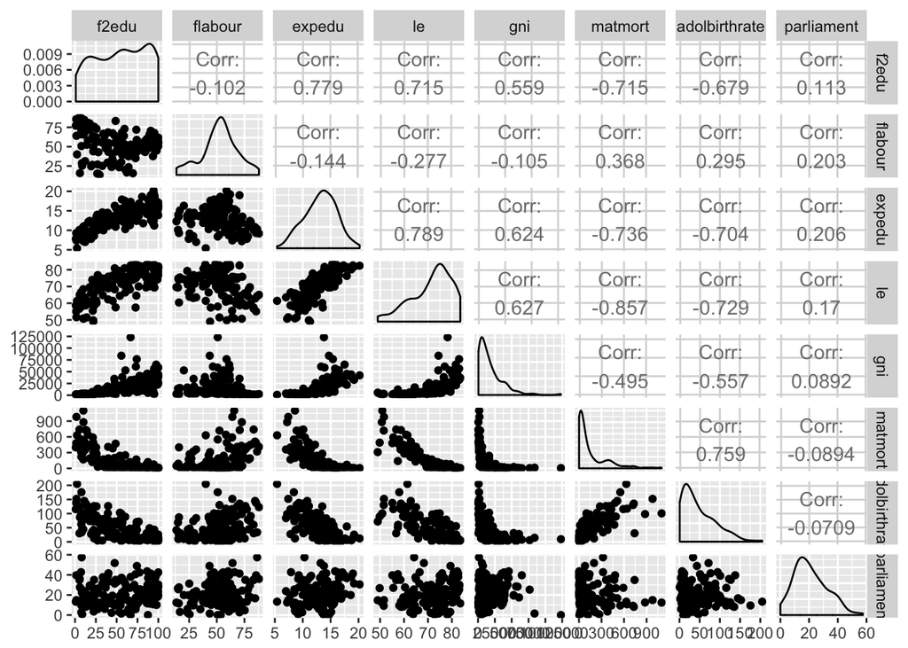

```r
library(GGally)
ggpairs(human)
```

If we look at the summary table, we can see that all variables vary strongly between the coutries. For instance, the proportion of women with a least secondary education ranges from 0.9% to 100% and female parliamentary representation from 0% to 57.5%. Some of the varibles have quite strong correlations with each other. For example, life expectancy is strongly associated with higher expected years of education and lower adolescent birth rate. On the other hand, female parliamentary representation does not show strong correlation with any of the other variables. Expected years of education is the only variable with somewhat normal distribution. For maternal mortality, there are a few countries with very high ratios but most countries fall to the lower end of the distribution.

## Principal component analysis (PCA)

Next, I will perform a principal component analysis on the data described above. I plot the results with a biplot that shows two of the most important principal components that were identified as x-axis and y-axis.

```r
#The model
pca_human <- prcomp(human)
summary(pca_human)
```

```
## Importance of components:
##                              PC1      PC2   PC3   PC4   PC5   PC6   PC7
## Standard deviation     1.854e+04 186.2835 25.97 20.07 14.32 10.63 3.721
## Proportion of Variance 9.999e-01   0.0001  0.00  0.00  0.00  0.00 0.000
## Cumulative Proportion  9.999e-01   1.0000  1.00  1.00  1.00  1.00 1.000
##                          PC8
## Standard deviation     1.428
## Proportion of Variance 0.000
## Cumulative Proportion  1.000
```

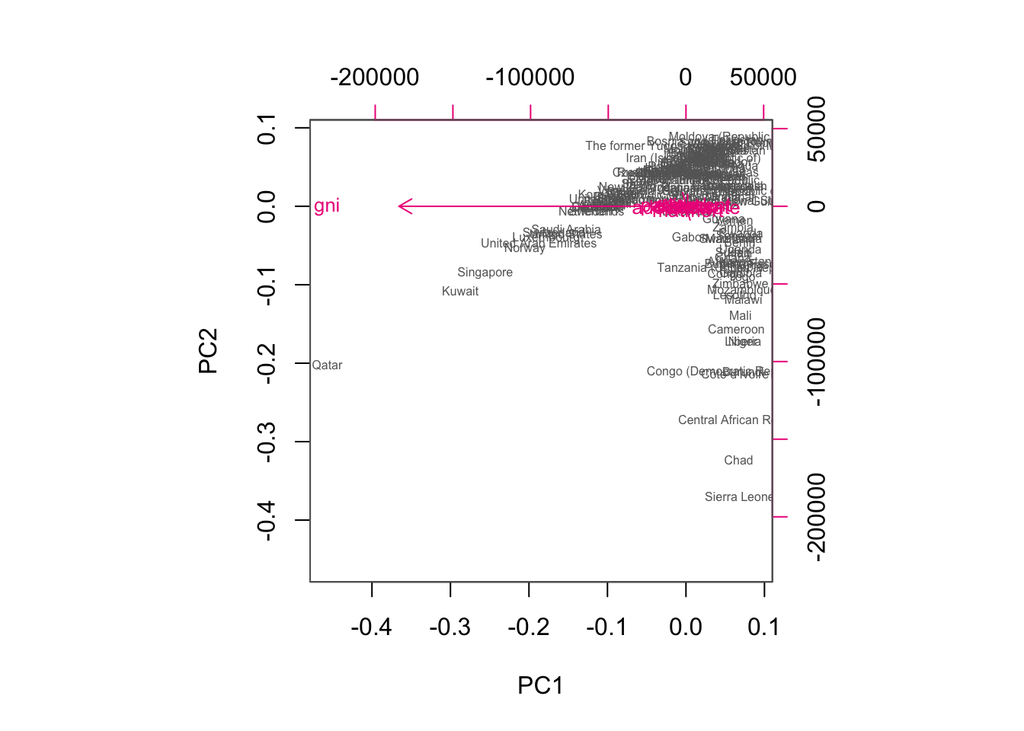

```r
biplot(pca_human, choices = 1:2, cex = c(0.5, 0.8), col = c("grey40", "deeppink2"))
```

The plot is quite difficult to read as most countries fall to the top right corner of it. Because we have not standardized the variables, gross national income (GNI) is the most significant due to its large variance. In fact, the first principal component seems to account for 100% of the variance. GNI defines the first principal component, but it is difficult to say what defines the second, as the other arrows are not drawn. Let’s rerun the analysis with scaled variables.

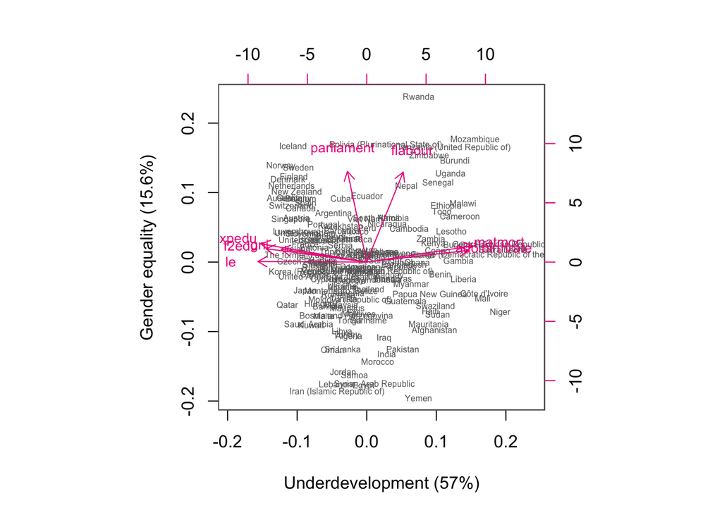

```r
#Scale
human_std <- scale(human)

#Estimation
pca_human <- prcomp(human_std)
s <- summary(pca_human)

# rounded percetanges of variance captured by each PC
pca_pr <- round(100*s$importance[2, ], digits = 1)

# create object pc_lab to be used as axis labels
pc_lab <- paste0(c("Underdevelopment", "Gender equality"), " (", pca_pr, "%)")

biplot(pca_human, choices = 1:2, cex = c(0.5, 0.8), col = c("grey40", "deeppink2"), xlab = pc_lab[1], ylab = pc_lab[2])
```

After scaling the variables, the plot becomes much clearer to interpret. The biplot arrows reveal that the first principal compoment measures human development or, more precisely, underdevelopment (high maternal mortality, low life expectancy, low education etc), whereas the second component measures gender equality separate of human development (female parliamentary representation and female labour market participation). It is easy to see why because when we looked at correlations, parliament and female labour were the only variables that did not have strong correlations with the other variables. I have also labeled the principal components in the plot accordingly. The proportions of variance accounted for by the components are shown in parenthesis. Human development component accounted for more than half of the variance. Because the negative values of human development component indicate high development, the Nordic countries (highly developed and high gender equality) can be found in the top-left corner of the plot. Interestingly, there are quite many underdeveloped countries with high equality and vice versa.

## Multiple correspondence analysis

Next, I move up to multiple correspondence analysis. Here I will use a data set that contains the answers of a questionnaire on tea consumption. I start by loading the data and exploring its structure and dimensions.

```r
library(FactoMineR)
data("tea")
str(tea)
```

```
## 'data.frame':    300 obs. of  36 variables:
##  $ breakfast       : Factor w/ 2 levels "breakfast","Not.breakfast": 1 1 2 2 1 2 1 2 1 1 ...
##  $ tea.time        : Factor w/ 2 levels "Not.tea time",..: 1 1 2 1 1 1 2 2 2 1 ...
##  $ evening         : Factor w/ 2 levels "evening","Not.evening": 2 2 1 2 1 2 2 1 2 1 ...
##  $ lunch           : Factor w/ 2 levels "lunch","Not.lunch": 2 2 2 2 2 2 2 2 2 2 ...
##  $ dinner          : Factor w/ 2 levels "dinner","Not.dinner": 2 2 1 1 2 1 2 2 2 2 ...
##  $ always          : Factor w/ 2 levels "always","Not.always": 2 2 2 2 1 2 2 2 2 2 ...
##  $ home            : Factor w/ 2 levels "home","Not.home": 1 1 1 1 1 1 1 1 1 1 ...
##  $ work            : Factor w/ 2 levels "Not.work","work": 1 1 2 1 1 1 1 1 1 1 ...
##  $ tearoom         : Factor w/ 2 levels "Not.tearoom",..: 1 1 1 1 1 1 1 1 1 2 ...
##  $ friends         : Factor w/ 2 levels "friends","Not.friends": 2 2 1 2 2 2 1 2 2 2 ...
##  $ resto           : Factor w/ 2 levels "Not.resto","resto": 1 1 2 1 1 1 1 1 1 1 ...
##  $ pub             : Factor w/ 2 levels "Not.pub","pub": 1 1 1 1 1 1 1 1 1 1 ...
##  $ Tea             : Factor w/ 3 levels "black","Earl Grey",..: 1 1 2 2 2 2 2 1 2 1 ...
##  $ How             : Factor w/ 4 levels "alone","lemon",..: 1 3 1 1 1 1 1 3 3 1 ...
```

[output cut: 22 more lines]

```r
dim(tea)
```

```
## [1] 300  36
```

This tea consumption data set has 300 obsevations (survey participants) and 36 variables (questions). The variables include questions on backbround factors (sex, age etc), tea consumption habits (frequency, during lunch, at work etc), and tea-related notions and attitudes (healthiness, femininity, relaxation).

To improve the clarity of the analysis, I will only select a subset of ten variables.

```r
library(dplyr)
```

```r
# column names to keep in the dataset
keep_columns <- c("Tea", "sex", "where", "SPC", "friends", "healthy", "sophisticated", "frequency", "breakfast", "lunch")

# select the 'keep_columns' to create a new dataset
tea_time <- select(tea, one_of(keep_columns))
```

Next, I will perform a multiple correspondence analysis on these ten variables.

```r
# multiple correspondence analysis
mca <- MCA(tea_time, graph = FALSE)

# summary of the model
summary(mca)
```

```
##
## Call:
## MCA(X = tea_time, graph = FALSE)
##
##
## Eigenvalues
##                        Dim.1   Dim.2   Dim.3   Dim.4   Dim.5   Dim.6
## Variance               0.174   0.166   0.144   0.138   0.122   0.118
## % of var.              9.169   8.726   7.557   7.283   6.395   6.237
## Cumulative % of var.   9.169  17.895  25.452  32.735  39.130  45.367
##                        Dim.7   Dim.8   Dim.9  Dim.10  Dim.11  Dim.12
## Variance               0.113   0.107   0.105   0.093   0.089   0.087
## % of var.              5.945   5.658   5.551   4.919   4.699   4.604
## Cumulative % of var.  51.312  56.970  62.520  67.439  72.138  76.742
##                       Dim.13  Dim.14  Dim.15  Dim.16  Dim.17  Dim.18
## Variance               0.075   0.073   0.070   0.065   0.059   0.054
## % of var.              3.927   3.855   3.666   3.432   3.105   2.820
## Cumulative % of var.  80.669  84.524  88.190  91.622  94.727  97.547
##                       Dim.19
## Variance               0.047
## % of var.              2.453
## Cumulative % of var. 100.000
##
## Individuals (the 10 first)
##                         Dim.1    ctr   cos2    Dim.2    ctr   cos2
## 1                    |  0.295  0.167  0.044 |  0.882  1.563  0.392 |
## 2                    |  0.096  0.017  0.005 |  0.732  1.078  0.281 |
## 3                    | -0.058  0.007  0.002 | -0.148  0.044  0.010 |
## 4                    |  0.416  0.330  0.146 | -0.076  0.011  0.005 |
## 5                    |  0.003  0.000  0.000 |  0.325  0.213  0.066 |
## 6                    |  0.320  0.196  0.074 |  0.045  0.004  0.001 |
## 7                    | -0.105  0.021  0.005 |  0.186  0.069  0.015 |
## 8                    |  0.511  0.500  0.128 | -0.101  0.021  0.005 |
## 9                    | -0.179  0.062  0.016 |  0.402  0.324  0.082 |
## 10                   | -0.282  0.152  0.035 |  0.920  1.703  0.378 |
##                       Dim.3    ctr   cos2
## 1                    -0.227  0.120  0.026 |
## 2                    -0.400  0.371  0.084 |
## 3                    -0.469  0.511  0.101 |
## 4                    -0.363  0.306  0.111 |
```

[output cut: 28 more lines]

```
## employee               0.001   0.602 |  -0.797   8.709   0.156  -6.822 |
## middle                 0.043   3.565 |   0.426   1.688   0.028   2.892 |
##
## Categorical variables (eta2)
##                        Dim.1 Dim.2 Dim.3
## Tea                  | 0.144 0.141 0.028 |
## sex                  | 0.168 0.089 0.103 |
## where                | 0.285 0.038 0.436 |
## SPC                  | 0.150 0.270 0.444 |
## friends              | 0.119 0.162 0.038 |
## healthy              | 0.011 0.136 0.050 |
## sophisticated        | 0.032 0.049 0.033 |
## frequency            | 0.405 0.391 0.184 |
## breakfast            | 0.206 0.351 0.023 |
## lunch                | 0.222 0.030 0.097 |
```

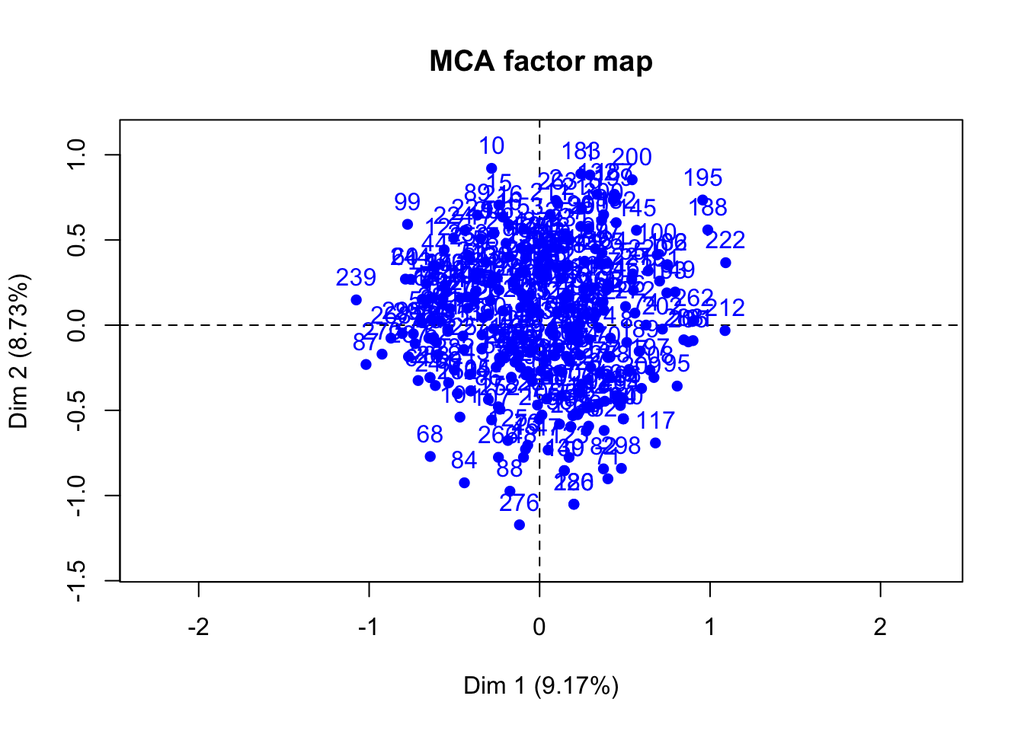

```r
# visualize MCA
plot(mca, invisible=c("var"), habillage = "quali")
```

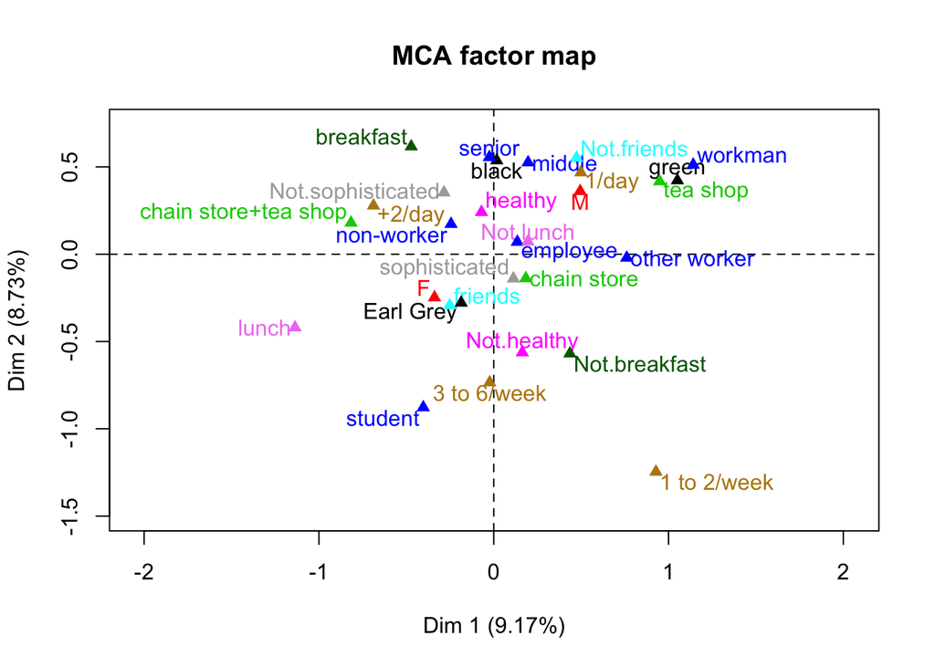

```r
plot(mca, invisible=c("ind"), habillage = "quali")
```

The first plot shows how the individuals divide on the two dimensions, while the second plot shows how the variables relate to the dimensions. We can see that most individuals fall in the middle of the plot and there are no clear outlier cases. This could be related to the fact that Both dimensions account for less than 10% of the variance.